# Vargas_Parra_Esteban_ADO_PEC2

Esteban Vargas Parra

13 junio, 2020

# Resumen

Para este estudio, se tuvo de referencia unas muestras del repositorio (GTEx^1), en éste se hallan datos de un total de 54 tejidos, focalizándose en los datos de expresión RNA-seq en un análisis de tiroides. Consta de tres tipos de infiltración diferente (NIT, SFI, ELI), de los cuales se tomaron 10 muestras aleatorias por cada tipo. Entre los grupos NIT y SFI no hubo alta cantidad de genes expresados diferencialmente, mientras que estos comparados con ELI sí presentaron un alto número de genes sobreexpresados y suprimidos[^1].

## Palabras claves

expresión, RNA-seq, genes.

# 1. Introducción

RNA-seq, proporciona una forma rentable de obtener grandes cantidades de datos de transcriptoma de una muestra biológica, para un estudio de interés. Estas técnicas basadas en secuenciación masiva eliminan el ruido introducido por la correcta hibridación de sondas dependiente del diseño empleado, ofrecen un mayor rango dinámico de detección al evitar la saturación por señales de fluorescencia y permiten obtener un panorama más global de los genes activados y/o reprimidos sin restringirse a genes previamente caracterizados Shin et al. (2019)

La tiroides, situada en el cuello, es una de las glándulas endocrinas que producen hormonas, controlando varias actividades del cuerpo, como lo son la velocidad con que se quema calorías, los latidos del corazón, entre otras Hernández, María, Milton Rendón (2019). En el presente estudio se tomaron en cuenta dos tipos de infiltración en un análisis de tiroides y un grupo sin tejidos filtrados (NIT), siendo los infiltrados, aquellos que tienen ligeros infiltrados focales (SFI) y los que poseen infiltrados linfoides extensos (ELI).

Como objetivo de este estudio, se pretende realizar un análisis comparativo de RNA-seq utilizando paquetes del programa Bioconductor.

# 2 Materiales

Los materiales de trabajo fueron proporcionados por el aula, éstos venían preprocedados en una tabla de contajes denominada counts y un archivo targets, los cuáles contienen datos múltiples en un total de 54 tejido, tomando de referencia aquellos RNA-seq pertenecientes a un análisis de tiroides donde se comparan tres tipos de infiltración en un total de 292 muestras.

- Not infiltrated tissues (NIT): 236 muestras
- Small focal infiltrates (SFI): 42 muestras
- Extensive lymphoid infiltrates (ELI): 14 muestras

## 2.1 Datos

Para la preparación de los datos, se pretende tomar aleatoriamente 10 por cada grupo, para así proceder a realizar un análisis de expresión diferencial (NIT-SFI, NIT-ELI y SFI-ELI).

## 2.2 Métodos

Para el siguiente estudio se siguieron los pasos del RNAseq pipeline - Bioconductor, Ricardo Gonzalo Sanz y Alex Sánchez-Pla (24 de mayo, 2020)

## 2.3 Software

El análisis de este trabajo se realizó con la versión de R 3.6.3 (2020-02-09). R es un leguaje para computación, estadísticas y gráficos, el cual proporciona una variedad de técnicas estadísticas y gráficas. R-Studio es una interfaz que facilita el uso, debido que posee un espacio más cómodo y gráfico.

## 2.4 Preparación de datos

El primer paso a realizar es cargar los archivos proporcionados (targets y counts), los cuales se enceuntran en formato csv, dentro del repositorio, el mismo al cual llegarán nuestros resultados exportados.

El archivo targets que contiene en el nombre del exprimento, nombre de la muestra, grupo de análisis, sitio del cuerpo, tipo de datos moleculares, sexo y nuestro grupo con el cual realizaremos nuestro diseño del experimento.

```
##   Experiment SRA_Sample              Sample_Name Grupo_analisis body_site
## 1  SRX567480  SRS626942 GTEX-111CU-0226-SM-5GZXC              1   Thyroid
## 2  SRX615964  SRS644174 GTEX-111FC-1026-SM-5GZX1              1   Thyroid
## 3  SRX563960  SRS625636 GTEX-111VG-0526-SM-5N9BW              3   Thyroid
## 4  SRX564185  SRS625665 GTEX-111YS-0726-SM-5GZY8              1   Thyroid
## 5  SRX559141  SRS624025 GTEX-1122O-0226-SM-5N9DA              1   Thyroid
## 6  SRX561718  SRS625313 GTEX-1128S-0126-SM-5H12S              1   Thyroid
##          molecular_data_type    sex Group ShortName
## 1 Allele-Specific Expression   male   NIT 111CU_NIT
## 2              RNA Seq (NGS)   male   NIT 111FC_NIT
## 3              RNA Seq (NGS)   male   ELI 111VG_ELI
## 4 Allele-Specific Expression   male   NIT 111YS_NIT
## 5              RNA Seq (NGS) female   NIT 1122O_NIT
## 6 Allele-Specific Expression female   NIT 1128S_NIT
```

En total se tienen un resultados de 292 muestras, de las cuales 236 pertenecen a NIT, 42 a SFI y 14 a ELI. Como propósito de este estudio, se debe seleccionar 10 muestras al azar para cada grupos (un total de 30 muestras en total). Es importante fijar una semilla, con el fin de poder replicar el ensayo y obtener siempre el mismo resultado

```
##  [1] NIT NIT NIT NIT NIT NIT NIT NIT NIT NIT SFI SFI SFI SFI SFI SFI SFI SFI SFI
## [20] SFI ELI ELI ELI ELI ELI ELI ELI ELI ELI ELI
## Levels: ELI NIT SFI
```

Por otra parte se administraron los archivos counts, pero para esto es importante observar que aquellos que traen el nombre del transcrito constan al final de “.” seguido de un número, el cual es recomendable eliminar para realizar los análisis.

```
##                V1                       V2                       V3
## 1     Sample_Name GTEX-111CU-0226-SM-5GZXC GTEX-111FC-1026-SM-5GZX1
## 2 ENSG00000223972                        7                        0
## 3 ENSG00000227232                      401                     1064
## 4 ENSG00000243485                        4                        0
## 5 ENSG00000237613                        2                        0
## 6 ENSG00000268020                        0                        0
```

Por otra parte, el encabezado se tomó como falso, con la idea de transponer la matriz y realizar una intersección, sabiendo que este encabezado posee la misma escritura de los resultados del vector Sample_Name del archivo target (Con la función join del paquete ply obtiene una intersección sin alterar el orden). Además, el archivo counts, desde el momento en el que se sube con un encabezado falso, todos sus valores tomarán carácterísticas cualitativas, por lo cual es necesario convertir la matriz de los conteos de factor a numérica una vez se haya realizado la intersección.

```
##                 146FR_NIT 11TTK_NIT ZGAY-_NIT OHPK-_NIT 145ME_NIT
## ENSG00000223972         0         3         1        17         1
## ENSG00000227232       514      1241       630       484       588
## ENSG00000243485         1         1         0        10         2
## ENSG00000237613         2         2         3         7         0
## ENSG00000268020         1         0         0         6         0
## ENSG00000240361         1         1         0         5         0
```

Para obtener unos resultados con unas etiquetas más sencillas, cambio el nombre de la filas por el nombre del vector Short_Name y posteriormente lo elimino.

```
##           Experiment SRA_Sample              Sample_Name Grupo_analisis
## 146FR_NIT  SRX634070  SRS648837 GTEX-146FR-0326-SM-5SI8U              1
## 11TTK_NIT  SRX569988  SRS627421 GTEX-11TTK-0826-SM-5N9EG              1
## ZGAY-_NIT  SRX566542  SRS626609  GTEX-ZGAY-1026-SM-4WWBR              1
## OHPK-_NIT  SRX199228  SRS333389  GTEX-OHPK-2626-SM-2HMK9              1
## 145ME_NIT  SRX636919  SRS649624 GTEX-145ME-0126-SM-5S2QM              1
## 14A6H_NIT  SRX571641  SRS627787 GTEX-14A6H-2426-SM-5Q5BO              1
##           body_site        molecular_data_type    sex Group
## 146FR_NIT   Thyroid Allele-Specific Expression female   NIT
## 11TTK_NIT   Thyroid              RNA Seq (NGS) female   NIT
## ZGAY-_NIT   Thyroid              RNA Seq (NGS) female   NIT
## OHPK-_NIT   Thyroid Allele-Specific Expression female   NIT
## 145ME_NIT   Thyroid              RNA Seq (NGS) female   NIT
## 14A6H_NIT   Thyroid Allele-Specific Expression   male   NIT
```

# 3. Objeto DESeqDataSet, la información de muestra y la fórmula de diseño

Al obtener únicamente la matriz de conteo y la tabla de información de la muestra. Se hace uso de la función DESeqDataSetFromMatrix (paquete DESeq2), permitiendo obtener un ensayo con la información de la muestra y la fórmula del diseño.

```r
dds <- DESeqDataSetFromMatrix(countData = tobjetivos,
                                 colData = target,
                                 design = ~Group)
dds
```

```
## class: DESeqDataSet
## dim: 56202 30
## metadata(1): version
## assays(1): counts
## rownames(56202): ENSG00000223972 ENSG00000227232 ... ENSG00000210195
##   ENSG00000210196
## rowData names(0):
## colnames(30): 146FR_NIT 11TTK_NIT ... 11NV4_ELI 14ABY_ELI
## colData names(8): Experiment SRA_Sample ... sex Group
```

## 3.1 Análisis exploratorio y visualización

### 3.1.1 Pre-filtraje del conjunto de datos

Nuestra matriz de conteo con nuestro DESeqDataSet contiene muchas filas con solo ceros, y adicionalmente muchas filas con solo unos pocos fragmentos en total. Para reducir el tamaño del objeto y aumentar la velocidad de nuestras funciones, podemos eliminar las filas que no tienen o casi no tienen información sobre la cantidad de expresión génica. Aquí aplicamos la regla de filtrado más mínima: eliminar filas del DESeqDataSet que no tienen recuentos, o solo un recuento único en todas las muestras. La ponderación / filtrado adicional para mejorar la potencia se aplica en un paso posterior en el flujo de trabajo. Aun así, este ensayo posee conteos bajos, sin saber qué criterio se puede establecer para aumentar el corte para tener más conteos o dejar todos los que son mayores a 1.

```
## [1] 56202
```

```
## [1] 43542
```

### 3.1.2 Transformación estabilizadora de la varianza

Dado el caso que se realizara un análisis de componente principales con los recuentos normalizados, el resultado de la gráfica tomará aquellos genes con valores de recuentos más altos, dejando de lado los de recuentos bajos. Para evitar esto, se decidió llevarlos valores a escalas logarítmicas, permitiendo que aquellos genes con contenos bajos contribuirán a una cantidad de ruido en la gráfica resultante.

Para realizar esta transformación se puede realizar con funciones que otorga DESeq2, como lo es vst y rlog, ambas son recomendables, con la diferencia que vst funciona para conjuntos medianos o grandes (n>30) y rlog para conjuntos pequeños (n<30), así, que para el respectivo estudio se implementa el uso de vst.

```
##                 146FR_NIT 11TTK_NIT ZGAY-_NIT OHPK-_NIT 145ME_NIT 14A6H_NIT
## ENSG00000223972  3.910961  4.442497  4.324332  5.276264  4.359969  3.910961
## ENSG00000227232  9.012766  9.788049  9.667398  8.789916  9.803356 10.703006
## ENSG00000243485  4.272057  4.218996  3.910961  4.973442  4.543444  4.491753
##                 ZVZP-_NIT 1192W_NIT 13FLV_NIT ZDYS-_NIT ZYVF-_SFI S341-_SFI
## ENSG00000223972  4.816513  4.594115  4.737966  4.692387  4.460994  4.444343
## ENSG00000227232  9.404350  9.422294 10.668020  9.242748  9.902577  8.979658
## ENSG00000243485  4.489251  4.307823  4.284846  4.519164  4.301063  4.289186
##                 OXRP-_SFI ZLV1-_SFI 13NZ8_SFI Q2AH-_SFI 13NYC_SFI 12584_SFI
## ENSG00000223972  4.436205  4.435919  4.257030  4.288190  3.910961  4.285964
## ENSG00000227232  9.713489  9.498862 10.025431  9.867015  9.552515 10.125886
## ENSG00000243485  4.516364  4.435919  4.399217  4.957847  3.910961  4.439823
##                 12ZZY_SFI R55E-_SFI R55G-_ELI YFC4-_ELI TMMY-_ELI 11XUK_ELI
## ENSG00000223972  4.467884  4.617140  5.059951  4.199083  4.443531  3.910961
## ENSG00000227232  9.196920  9.415681  8.903251  9.839071  9.464195  8.936466
## ENSG00000243485  4.467884  4.321371  4.585832  4.199083  4.443531  3.910961
##                 ZYY3-_ELI 111VG_ELI 13NZ9_ELI YJ89-_ELI 11NV4_ELI 14ABY_ELI
## ENSG00000223972  4.864193  4.298773  3.910961  4.512122  4.533432  4.250092
## ENSG00000227232 10.190063  9.098025  9.641105  9.825918 10.302938  9.402795
## ENSG00000243485  4.305999  4.298773  4.236074  4.213168  4.272194  4.389473
```

```
## DataFrame with 6 rows and 9 columns
##           Experiment SRA_Sample              Sample_Name Grupo_analisis
##             <factor>   <factor>                 <factor>      <integer>
## 146FR_NIT  SRX634070  SRS648837 GTEX-146FR-0326-SM-5SI8U              1
## 11TTK_NIT  SRX569988  SRS627421 GTEX-11TTK-0826-SM-5N9EG              1
## ZGAY-_NIT  SRX566542  SRS626609  GTEX-ZGAY-1026-SM-4WWBR              1
## OHPK-_NIT  SRX199228  SRS333389  GTEX-OHPK-2626-SM-2HMK9              1
## 145ME_NIT  SRX636919  SRS649624 GTEX-145ME-0126-SM-5S2QM              1
## 14A6H_NIT  SRX571641  SRS627787 GTEX-14A6H-2426-SM-5Q5BO              1
##           body_site        molecular_data_type      sex    Group
##            <factor>                   <factor> <factor> <factor>
## 146FR_NIT   Thyroid Allele-Specific Expression   female      NIT
## 11TTK_NIT   Thyroid              RNA Seq (NGS)   female      NIT
## ZGAY-_NIT   Thyroid              RNA Seq (NGS)   female      NIT
## OHPK-_NIT   Thyroid Allele-Specific Expression   female      NIT
## 145ME_NIT   Thyroid              RNA Seq (NGS)   female      NIT
## 14A6H_NIT   Thyroid Allele-Specific Expression     male      NIT
##                  sizeFactor
##                   <numeric>
## 146FR_NIT  1.05564966238494
## 11TTK_NIT  1.45271723338216
## ZGAY-_NIT 0.804233280824579
## OHPK-_NIT  1.17178872314706
## 145ME_NIT 0.680801209267189
## 14A6H_NIT 0.809400797308193
```

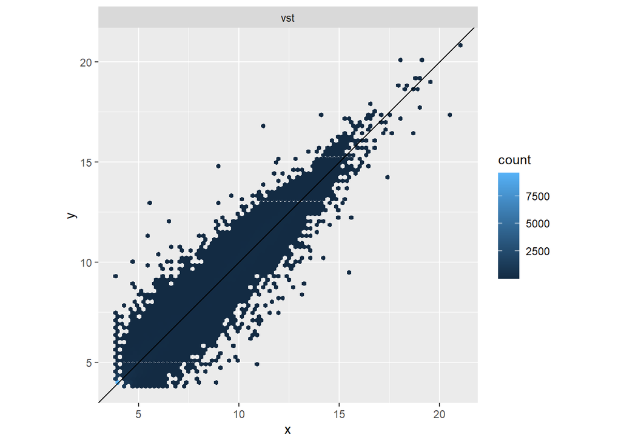

Al ver este diagrama de dispersión en general, una agrupación más cercana de todos los puntos de datos a lo largo de la diagonal indicarían tratamientos que tienen patrones de expresión muy similares en todos los genes, mientras que una mayor difusión de los puntos de datos desde la diagonal indicaría niveles de expresión menos similares.

### 3.1.2 Distancias de las muestras

El cálculo de la distancia euclidiana otorga la similitud general entre muestras, para garantizar una contribución igual entre todos los genes. Es necesario transponer la matriz, para que las diferentes muestras sean filas de sus argumento y diferentes dimensiones sean columnas.

```
##           146FR_NIT 11TTK_NIT ZGAY-_NIT OHPK-_NIT 145ME_NIT 14A6H_NIT ZVZP-_NIT
## 11TTK_NIT  129.4772
## ZGAY-_NIT  104.9414  124.3219
## OHPK-_NIT  120.8076  133.6621  103.5679
## 145ME_NIT  131.8594  149.8662  122.5269  117.0147
## 14A6H_NIT  124.2956  106.2518  119.2110  135.6057  143.5656
## ZVZP-_NIT  107.5847  136.5686  109.1872  115.5333  134.0381  129.7651
## 1192W_NIT  127.5595  112.3106  123.2079  135.0428  153.2505  108.4749  128.7174
## 13FLV_NIT  125.7576  128.6457  127.7290  138.3389  152.6586  119.9911  132.0384
## ZDYS-_NIT  114.3914  138.2191  107.6249  111.7971  118.8972  131.7398  118.4070
## ZYVF-_SFI  116.8617  112.2062  116.8010  124.3850  125.3906  114.0086  125.8626
## S341-_SFI  103.3403  135.8693  104.8059  110.3649  119.1834  132.7296  104.1595
## OXRP-_SFI  127.1184  117.1147  132.8208  135.3815  147.3142  130.2167  131.8151
## ZLV1-_SFI  170.1427  195.9913  163.8116  167.3959  139.8172  189.5612  179.5111
## 13NZ8_SFI  135.0706  134.5815  138.9175  143.6888  148.4030  135.9906  149.0804
## Q2AH-_SFI  127.5894  146.4250  122.3564  112.2638  104.2043  136.7261  128.0667
## 13NYC_SFI  142.6035  119.9780  142.4980  145.1566  140.1474  123.0343  142.5387
## 12584_SFI  138.7323  133.6577  141.6078  157.6979  165.5646  121.4941  148.4856
## 12ZZY_SFI  123.7108  136.4406  118.9002  129.1158  136.9767  124.2687  129.9750
## R55E-_SFI  134.3097  120.6929  125.2450  124.3117  154.4367  115.7901  131.1657
## R55G-_ELI  165.7216  182.6884  157.4652  156.2767  142.7884  175.8389  175.8665
## YFC4-_ELI  186.1238  192.8251  184.1352  187.0019  162.4700  182.5175  203.8316
## TMMY-_ELI  167.3249  192.8420  166.3002  169.4467  152.0177  186.0698  180.1011
## 11XUK_ELI  184.1328  207.2280  182.4138  189.0693  164.7059  197.1896  203.5621
## ZYY3-_ELI  156.5905  156.1567  145.3317  150.5705  134.1698  156.2439  168.1006
## 111VG_ELI  158.0481  159.3411  143.7362  152.7280  142.1578  141.5211  162.9469
## 13NZ9_ELI  155.8075  164.1734  151.6885  156.4525  136.0555  146.4994  166.9712
## YJ89-_ELI  146.4852  133.3156  140.2883  149.8216  139.8917  127.5200  155.7121
## 11NV4_ELI  186.0318  191.9394  182.7300  185.6923  162.1169  181.7022  197.2650
## 14ABY_ELI  122.9459  127.5853  126.8304  137.6260  144.2416  126.6400  130.6708
##           1192W_NIT 13FLV_NIT ZDYS-_NIT ZYVF-_SFI S341-_SFI OXRP-_SFI ZLV1-_SFI
## 11TTK_NIT
## ZGAY-_NIT
## OHPK-_NIT
## 145ME_NIT
## 14A6H_NIT
## ZVZP-_NIT
## 1192W_NIT
## 13FLV_NIT  106.1305
## ZDYS-_NIT  133.9071  133.7222
```

[output cut: 95 more lines]

```
## Q2AH-_SFI
## 13NYC_SFI
## 12584_SFI
## 12ZZY_SFI
## R55E-_SFI
## R55G-_ELI
## YFC4-_ELI
## TMMY-_ELI
## 11XUK_ELI
## ZYY3-_ELI
## 111VG_ELI
## 13NZ9_ELI
## YJ89-_ELI
## 11NV4_ELI
## 14ABY_ELI  160.6923
```

A partir de las distancias, se puede generar un mapa de calor, que agrupa aquellas muestras que mayor similitud presentan.

```
## Found more than one class "unit" in cache; using the first, from namespace 'ggbio'
```

```
## Also defined by 'hexbin'
```

```
## Found more than one class "unit" in cache; using the first, from namespace 'ggbio'
```

```
## Also defined by 'hexbin'
```

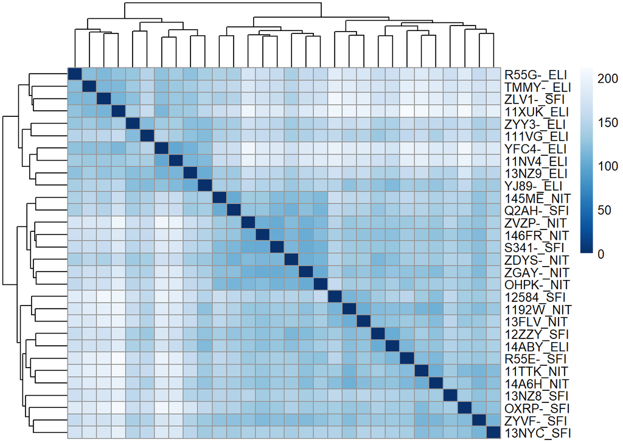

Otra forma de visualizar las muestras, es por medio del análisis de componentes principales, el cual ordena las muestras en forma de puntos en un plano 2D, agrupando aquellos que mayor similitud presentan. El resultado obtenido por el PCA, muestra como hay tendencia de que el grupo ELI tenga diferencias respecto a los otros grupos, mientas que entre el grupo NIT y SFI parece haber similitudes.

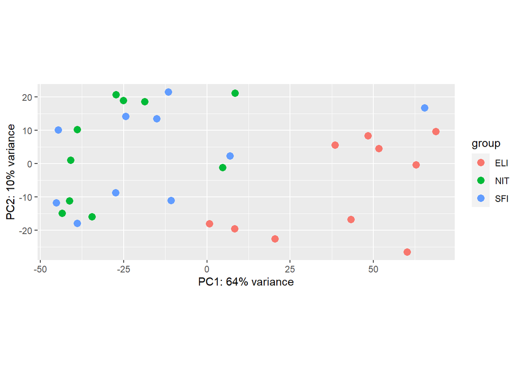

# 4. Análisis de expresión diferencial

El análisis de expresión diferencial se puede canalizar con los recuentos sin procesar. Estimando los factores de tamaño, valore de dispersión por cada gen y el ajuste de modelo lineal generalizado.

```
## -- replacing outliers and refitting for 294 genes
## -- DESeq argument 'minReplicatesForReplace' = 7
## -- original counts are preserved in counts(dds)
```

```
## class: DESeqDataSet
## dim: 43542 30
## metadata(1): version
## assays(6): counts mu ... replaceCounts replaceCooks
## rownames(43542): ENSG00000223972 ENSG00000227232 ... ENSG00000210195
##   ENSG00000210196
## rowData names(27): baseMean baseVar ... maxCooks replace
## colnames(30): 146FR_NIT 11TTK_NIT ... 11NV4_ELI 14ABY_ELI
## colData names(10): Experiment SRA_Sample ... sizeFactor replaceable
```

## 4.1 Construcción de tabla de resultados

El objetivo del estudio es realizar una comparación entre los grupos NIT-SFI, NIT-ELI y SFI-ELI. En este orden serán presentados los resultados, además se analizará al tiempo el plotCounts, el cual toma el nombre del gen (en este caso el topGene de cada contraste) y el grupo sobre el cual trazar los recuentos.

La comparación entre NIT-SFI muestra pocos genes con una diferencias significativa. Tomando sólo 6 como sobreexpresados y 31 como suprimidos, teniendo porcentajes bastante bajos.

```
## DataFrame with 6 rows and 2 columns
##                        type                               description
##                 <character>                               <character>
## baseMean       intermediate mean of normalized counts for all samples
## log2FoldChange      results  log2 fold change (MLE): Group NIT vs SFI
## lfcSE               results          standard error: Group NIT vs SFI
## stat                results          Wald statistic: Group NIT vs SFI
## pvalue              results       Wald test p-value: Group NIT vs SFI
## padj                results                      BH adjusted p-values
```

```
##
## out of 43537 with nonzero total read count
## adjusted p-value < 0.1
## LFC > 0 (up)       : 6, 0.014%
## LFC < 0 (down)     : 31, 0.071%
## outliers [1]       : 0, 0%
## low counts [2]     : 21107, 48%
## (mean count < 9)
## [1] see 'cooksCutoff' argument of ?results
## [2] see 'independentFiltering' argument of ?results
```

```
## [1] 37
```

```
## log2 fold change (MLE): Group NIT vs SFI
## Wald test p-value: Group NIT vs SFI
## DataFrame with 6 rows and 6 columns
##                         baseMean    log2FoldChange              lfcSE
##                        <numeric>         <numeric>          <numeric>
## ENSG00000225972 620.428645667486  4.67556473991517  0.883161916356583
## ENSG00000261003 16.2375970239162  3.16686432842087  0.821631405795888
## ENSG00000263826 77.6416157768781  1.19974157235881  0.315895544651727
## ENSG00000184923 62.8283192428661  1.15280536025159  0.287556543131963
## ENSG00000214456 1022.30040843191 0.956117182642483  0.250139226499448
## ENSG00000112651 1464.77021007598 0.276684047833147 0.0720906409260675
##                             stat               pvalue                padj
##                        <numeric>            <numeric>           <numeric>
## ENSG00000225972 5.29411951910682 1.19591201730369e-07 0.00268302861082082
## ENSG00000261003 3.85436134266707 0.000116032119908918  0.0956680691748131
## ENSG00000263826 3.79790596186316 0.000145923660580351   0.097662133156183
## ENSG00000184923 4.00896932372202 6.09843372282575e-05  0.0797204827448612
## ENSG00000214456 3.82234004647245 0.000132191225514562  0.0956680691748131
## ENSG00000112651 3.83800232982948 0.000124039305626761  0.0956680691748131
```

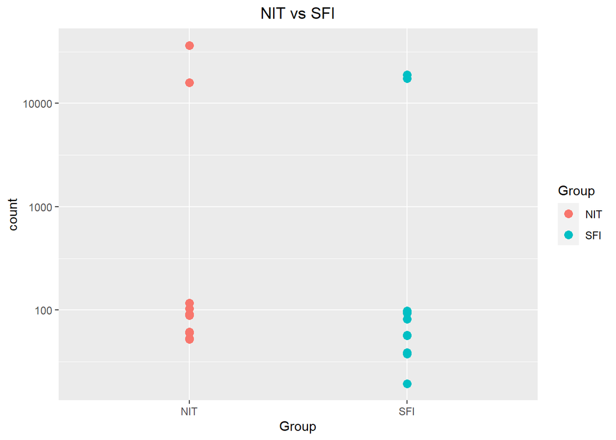

Por otra parte entre NIT-ELI, los genes con una expresión diferencial significativa fueron más altos que el anterior contraste. Mostrando un número de 2411 genes sobreexpresados y 4349 suprimidos.

```
## DataFrame with 6 rows and 2 columns
##                        type                               description
##                 <character>                               <character>
## baseMean       intermediate mean of normalized counts for all samples
## log2FoldChange      results  log2 fold change (MLE): Group NIT vs ELI
## lfcSE               results          standard error: Group NIT vs ELI
## stat                results          Wald statistic: Group NIT vs ELI
## pvalue              results       Wald test p-value: Group NIT vs ELI
## padj                results                      BH adjusted p-values
```

```
##
## out of 43537 with nonzero total read count
## adjusted p-value < 0.1
## LFC > 0 (up)       : 2411, 5.5%
## LFC < 0 (down)     : 4349, 10%
## outliers [1]       : 0, 0%
## low counts [2]     : 12666, 29%
## (mean count < 1)
## [1] see 'cooksCutoff' argument of ?results
## [2] see 'independentFiltering' argument of ?results
```

```
## [1] 6760
```

```
## log2 fold change (MLE): Group NIT vs ELI
## Wald test p-value: Group NIT vs ELI
## DataFrame with 6 rows and 6 columns
##                         baseMean    log2FoldChange            lfcSE
##                        <numeric>         <numeric>        <numeric>
## ENSG00000181617 397.714491830672 -9.95156283481491 1.62153984405085
## ENSG00000162897 73.2857246320937 -9.27897449744416 1.66500236998815
## ENSG00000170054 59.1750938824817 -9.22143186798561  1.5540337153778
## ENSG00000254029 19.1546513667177  -8.2132210024942  1.6716255854879
## ENSG00000100721  442.02767013681 -7.80577411875254  1.1546091973004
## ENSG00000271046 47.1716228956858 -7.68326129871508 1.32083220312945
##                              stat               pvalue                 padj
##                         <numeric>            <numeric>            <numeric>
## ENSG00000181617 -6.13710657269723 8.40380121360354e-10 1.16356845861535e-07
## ENSG00000162897  -5.5729497234951  2.5046187037084e-08 1.79426002542228e-06
## ENSG00000170054 -5.93386860062028 2.95878659464929e-09  3.2626962462997e-07
## ENSG00000254029 -4.91331376702815 8.95497920538851e-07 3.43799236937525e-05
## ENSG00000100721  -6.7605334662181 1.37484567039978e-11 4.08170528069843e-09
## ENSG00000271046   -5.816985140513 5.99184660109891e-09 5.82341447008893e-07
```

```
## log2 fold change (MLE): Group NIT vs ELI
## Wald test p-value: Group NIT vs ELI
## DataFrame with 6 rows and 6 columns
##                         baseMean   log2FoldChange             lfcSE
##                        <numeric>        <numeric>         <numeric>
## ENSG00000079689 89.4735422336761 5.21494637493474 0.937643487556841
## ENSG00000236848 18.2218349009803 4.30809379016599  1.30973348121989
## ENSG00000204437 2.29796954923941 4.27486467290217  1.17984011297172
## ENSG00000261829 1.98862729280263  4.1409638949691  1.45111469490002
## ENSG00000253301  6.5853542413093 3.96730070114239  1.43897244765102
## ENSG00000110680 388.032761860118 3.96268600518697  1.22696398507081
##                             stat               pvalue                 padj
##                        <numeric>            <numeric>            <numeric>
## ENSG00000079689 5.56175822062498 2.67070136378346e-08 1.87837301385372e-06
## ENSG00000236848 3.28929041819518  0.00100440327745496    0.010167854293344
## ENSG00000204437 3.62325761423289 0.000290915817990029  0.00388172722396722
## ENSG00000261829 2.85364341600469  0.00432210143817179   0.0310274829121117
## ENSG00000253301 2.75703729256153  0.00583276988977616   0.0388046979350849
## ENSG00000110680 3.22966774363658  0.00123934154588419   0.0120144143079184
```

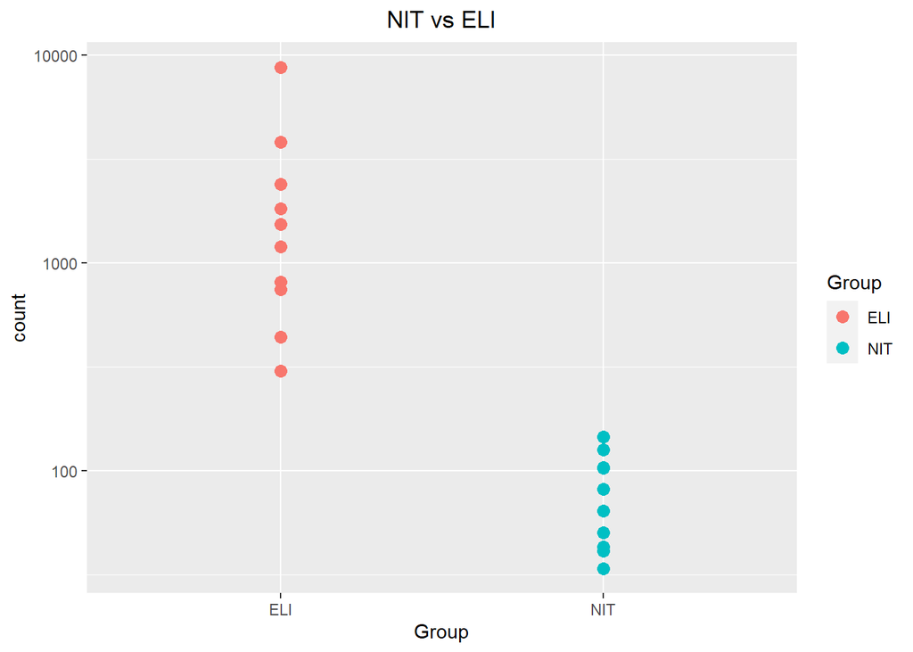

```
## DataFrame with 6 rows and 2 columns
##                        type                               description
##                 <character>                               <character>
## baseMean       intermediate mean of normalized counts for all samples
## log2FoldChange      results  log2 fold change (MLE): Group SFI vs ELI
## lfcSE               results          standard error: Group SFI vs ELI
## stat                results          Wald statistic: Group SFI vs ELI
## pvalue              results       Wald test p-value: Group SFI vs ELI
## padj                results                      BH adjusted p-values
```

```
##
## out of 43537 with nonzero total read count
## adjusted p-value < 0.1
## LFC > 0 (up)       : 1455, 3.3%
## LFC < 0 (down)     : 2700, 6.2%
## outliers [1]       : 0, 0%
## low counts [2]     : 13510, 31%
## (mean count < 1)
## [1] see 'cooksCutoff' argument of ?results
## [2] see 'independentFiltering' argument of ?results
```

```
## [1] 4155
```

```
## log2 fold change (MLE): Group SFI vs ELI
## Wald test p-value: Group SFI vs ELI
## DataFrame with 6 rows and 6 columns
##                         baseMean   log2FoldChange             lfcSE
##                        <numeric>        <numeric>         <numeric>
## ENSG00000100604  110.39787020852 4.93702207304453  1.08534982121309
## ENSG00000110680 388.032761860118 4.77461210816161  1.22685912429242
## ENSG00000226482 1.45492236026644 4.03991902825215  1.26907660268392
## ENSG00000079689 89.4735422336761 3.99764044273302 0.938379766239388
## ENSG00000232893 3.08499393572783 3.89875796788943   1.3714043913265
## ENSG00000181092  462.60885431391 3.87587520581623  1.08301163834021
##                             stat               pvalue                padj
##                        <numeric>            <numeric>           <numeric>
## ENSG00000100604 4.54878415838908 5.39567492445455e-06  0.0004669824476404
## ENSG00000110680 3.89173623411352 9.95294153368863e-05 0.00356265482884073
## ENSG00000226482 3.18335317167482  0.00145579926732611  0.0221594341593196
## ENSG00000079689 4.26015200514585 2.04287922345656e-05 0.00120533887699111
## ENSG00000232893 2.84289447558085  0.00447058694523283  0.0472582425692475
## ENSG00000181092 3.57879367922238 0.000345183833577851 0.00837742111720993
```

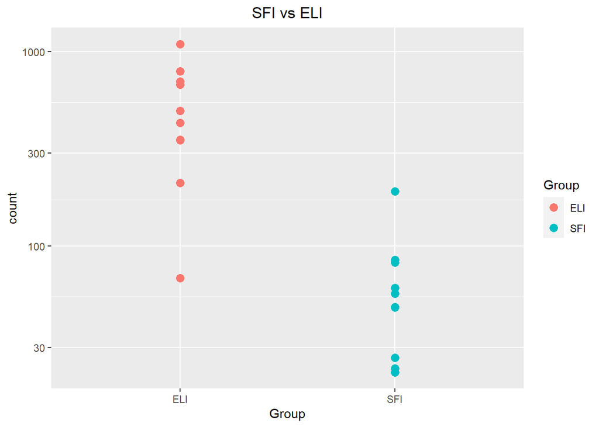

Adelantándonos a las conclusiones, entre NIT y SFI las diferencias son pocas, algo que se observó anteriormente con el HeatMap y el PCA, mientras que el grupo ELI, posee grandes diferencias de genes expresados diferencialmente respectos a los demás.

## 4.2 MA-plot

Este tipo de gráfico, realiza la comparación entre dos grupos, donde se visualiza como un diagrama de dispersión con cambio de pliegue de base 2 a lo largo del eje Y y expresión media normalizada a lo largo del eje X. Aquellos datos que se encuentren extremos sobre el eje Y, ya sea hacia arriba o abajo del cero, significa que son genes altamente diferenciados.

[output not shown]

[figure not shown]

## 4.3 Agrupación de genes

A partir de los datos obtenidos en la transformación estabilizadora de la varianza (vts), se hace un mapa de calor donde se determina la cantidad en que cada gen se desvía en una muestra específica del promedio del gen en todas las muestras. Para la demostración, se toman los 20 genes con una mayor varianza entre las muestras.

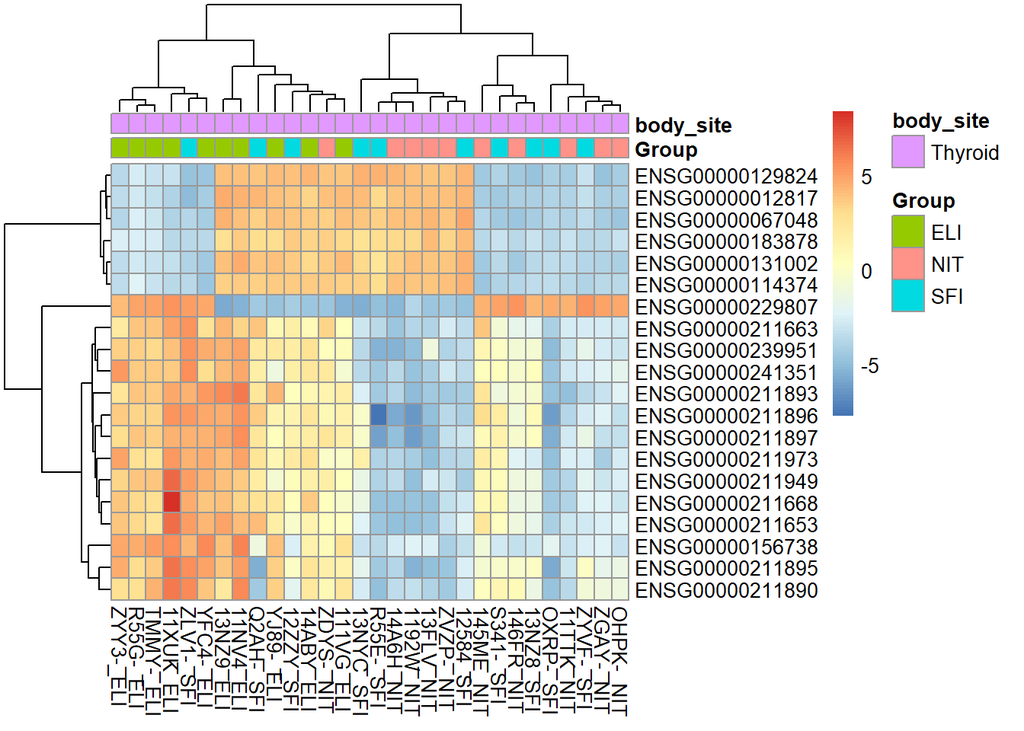

## 5. Anotación y exportación de resultados

Los resultados sólo contienen los ID de genes de ENSEMBL, pero los nombres alternativos puede ser más informativos para la interpretación. Se usó el paquete de anotación del organismo (“org”) para *Homo Sapiens*, organizado en un paquete de base de datos de AnnotationDbi (“db”), usando ID de genes de Entrez (“eg”) como clave principal.Para la exportación de los resultados, a través del paquete Bioconductor ReportingTools, el cual genera documentos html dinámicos, incluido enlaces a bases de datos externas utilizando identificadores de genes y diagramas de caja que resumen los recuentos normalizados entre los grupos.

```
##  [1] "ACCNUM"       "ALIAS"        "ENSEMBL"      "ENSEMBLPROT"  "ENSEMBLTRANS"
##  [6] "ENTREZID"     "ENZYME"       "EVIDENCE"     "EVIDENCEALL"  "GENENAME"
## [11] "GO"           "GOALL"        "IPI"          "MAP"          "OMIM"
## [16] "ONTOLOGY"     "ONTOLOGYALL"  "PATH"         "PFAM"         "PMID"
## [21] "PROSITE"      "REFSEQ"       "SYMBOL"       "UCSCKG"       "UNIGENE"
## [26] "UNIPROT"
```

```
## log2 fold change (MAP): Group NIT vs SFI
## Wald test p-value: Group NIT vs SFI
## DataFrame with 6 rows and 8 columns
##                         baseMean    log2FoldChange             lfcSE
##                        <numeric>         <numeric>         <numeric>
## ENSG00000225972 620.428645667486  0.35148814333481 0.540111649453477
## ENSG00000211892 14901.2843301904 -1.94365872675224 0.550900796231086
## ENSG00000254709 113.729703316433  -1.5389280344944 0.551991584534916
## ENSG00000213700 36.0182080962663 -1.71410811284893 0.378982213554683
## ENSG00000117322 1096.19287513499 -1.47556397119814 0.550979317047342
## ENSG00000211669 464.006050225524 -1.72319361218935 0.554174946194415
##                              stat               pvalue                padj
##                         <numeric>            <numeric>           <numeric>
## ENSG00000225972  5.29411951910682 1.19591201730369e-07 0.00268302861082082
## ENSG00000211892 -4.81361062853003 1.48227483538953e-06  0.0166274179659821
## ENSG00000254709 -4.57876354269815 4.67732582142936e-06  0.0349786016012559
## ENSG00000213700 -4.51309741202073 6.38876603128231e-06  0.0358329914779547
## ENSG00000117322 -4.41334514417585 1.01785531058556e-05  0.0364096189014579
## ENSG00000211669 -4.39477834806247 1.10885837866198e-05  0.0364096189014579
##                      symbol      entrez
##                 <character> <character>
## ENSG00000225972          NA          NA
## ENSG00000211892          NA          NA
## ENSG00000254709       IGLL5   100423062
## ENSG00000213700          NA          NA
## ENSG00000117322         CR2        1380
## ENSG00000211669          NA          NA
```

```
## log2 fold change (MAP): Group NIT vs ELI
## Wald test p-value: Group NIT vs ELI
## DataFrame with 6 rows and 8 columns
##                         baseMean    log2FoldChange             lfcSE
##                        <numeric>         <numeric>         <numeric>
## ENSG00000230006 861.079090733358 -3.79406930734551 0.448042557798252
## ENSG00000128218 189.180962958263 -3.91064022357866 0.457905449259739
## ENSG00000105255 42.7419635446247 -2.98632996919973 0.361820963881565
## ENSG00000204475 72.7777064242571 -3.42255141361848  0.42646052784608
## ENSG00000148600 213.004684902527 -2.82169252447532 0.355752623927361
## ENSG00000144645 1204.45275205121 -1.21756919233748    0.154392785531
##                              stat               pvalue                 padj
##                         <numeric>            <numeric>            <numeric>
## ENSG00000230006 -8.48910863858131  2.0822800135103e-17 3.42461987400505e-13
## ENSG00000128218 -8.48175066677341 2.21830539837093e-17 3.42461987400505e-13
## ENSG00000105255 -8.16097835519626 3.32321724028066e-16 3.42025518369686e-12
## ENSG00000204475 -7.92465927785793 2.28772742377751e-15 1.60772926304632e-11
## ENSG00000148600 -7.89196851646606 2.97456779614599e-15 1.60772926304632e-11
## ENSG00000144645 -7.88584144192936 3.12423098143475e-15 1.60772926304632e-11
##                      symbol      entrez
##                 <character> <character>
## ENSG00000230006  ANKRD36BP2      645784
## ENSG00000128218      VPREB3       29802
## ENSG00000105255        FSD1       79187
## ENSG00000204475        NCR3      259197
## ENSG00000148600       CDHR1       92211
## ENSG00000144645     OSBPL10      114884
```

```
## log2 fold change (MAP): Group SFI vs ELI
## Wald test p-value: Group SFI vs ELI
## DataFrame with 6 rows and 8 columns
##                         baseMean    log2FoldChange             lfcSE
##                        <numeric>         <numeric>         <numeric>
## ENSG00000148600 213.004684902527  -2.6840700166366 0.355268129717831
## ENSG00000148204 83.3953525137467 -2.64414649895211 0.372056009563629
## ENSG00000105255 42.7419635446247 -2.41765484181458 0.355797808574044
## ENSG00000181074 42.7924903892135 -2.63231274101238 0.394044984404743
## ENSG00000226423 6.61278456368124 -3.72768475680195 0.516526674405443
## ENSG00000260682 535.916844544249 -1.98428414273127 0.304951028187883
##                              stat               pvalue                 padj
##                         <numeric>            <numeric>            <numeric>
## ENSG00000148600 -7.51370442943738 5.74772747164649e-14 1.72615751428487e-09
## ENSG00000148204 -7.06513278666886 1.60462477374084e-12 2.40950456024924e-08
## ENSG00000105255 -6.72879704318651 1.71071470694851e-11 1.71253946930259e-07
## ENSG00000181074 -6.63150249777337 3.32286917747142e-11 2.49481017844554e-07
## ENSG00000226423 -6.55123192845234  5.7064351559339e-11 3.42751321206014e-07
## ENSG00000260682 -6.49143399166927 8.50231623172567e-11 3.94271151922183e-07
##                      symbol      entrez
##                 <character> <character>
## ENSG00000148600       CDHR1       92211
## ENSG00000148204        CRB2      286204
## ENSG00000105255        FSD1       79187
## ENSG00000181074      OR52N4      390072
## ENSG00000226423          NA          NA
## ENSG00000260682          NA          NA
```

# 6. Análisis de significancia biológica

Con la lista de genes diferencialmente expresados entre dos condiciones, se busca establecer si las funciones, procesos biológicos o vías moleculares que los caracterizan aparecen en esta lista con más frecuencia que entre el resto de los genes analizado Gonzalo and Sanchez-Pla (2020), determinando diferencias concordantes estadísticamente significativas entre dos estados biológicos.

Con el paquete clusterProfiler, realiza análisis estadístico y visualización de perfiles funcionales para genes y grupos de genes El paquete implementa métodos para analizar y visualizar perfiles funcionales de genes y grupos de genes.

Para este estudio se usó la función groupGo, que da la opción de elegir subontologías, en este caso se trabajó con “BP” que hacer referencias a procesos biológicos. También se puede usar “CC” que son componente celulares y “MF” que son funciones moleculares. Como los resultados obtenidos ELI comparados con los otros grupos son de gran tamaño, para mostrar la red de este análisis, sólo se tomó la comparación entre NIT-SFI.

[output not shown]

```
##                    ID            Description Count GeneRatio
## GO:0000003 GO:0000003           reproduction     2      2/25
## GO:0008152 GO:0008152      metabolic process    11     11/25
## GO:0001906 GO:0001906           cell killing     0      0/25
## GO:0002376 GO:0002376  immune system process     6      6/25
## GO:0006791 GO:0006791     sulfur utilization     0      0/25
## GO:0006794 GO:0006794 phosphorus utilization     0      0/25
##                                                                      geneID
## GO:0000003                                                         PNOC/TNC
## GO:0008152 IGLL5/CR2/AZGP1/MIXL1/P4HA1/FCRL3/FBXO39/TNC/TMPRSS4/MRPL2/PLIN5
## GO:0001906
## GO:0002376                             IGLL5/CR2/AZGP1/MIXL1/FCRL3/TMEM176A
## GO:0006791
## GO:0006794
```

[figure not shown]

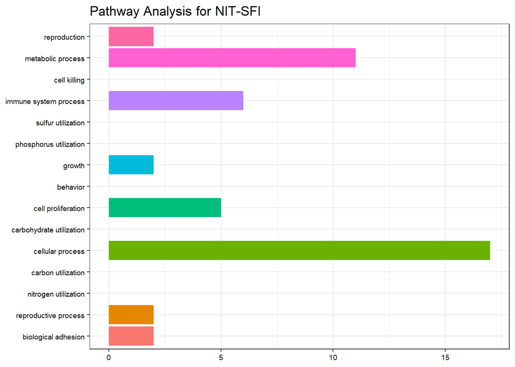

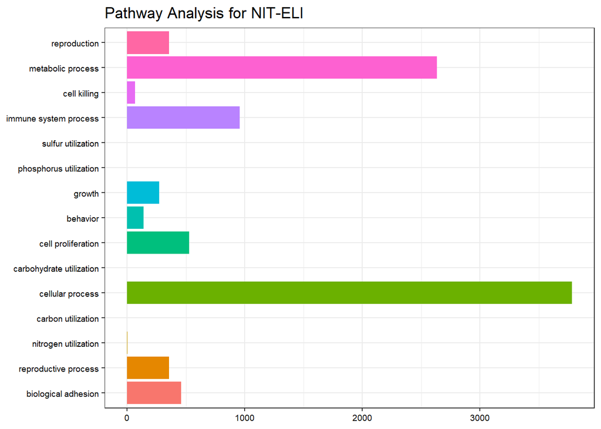

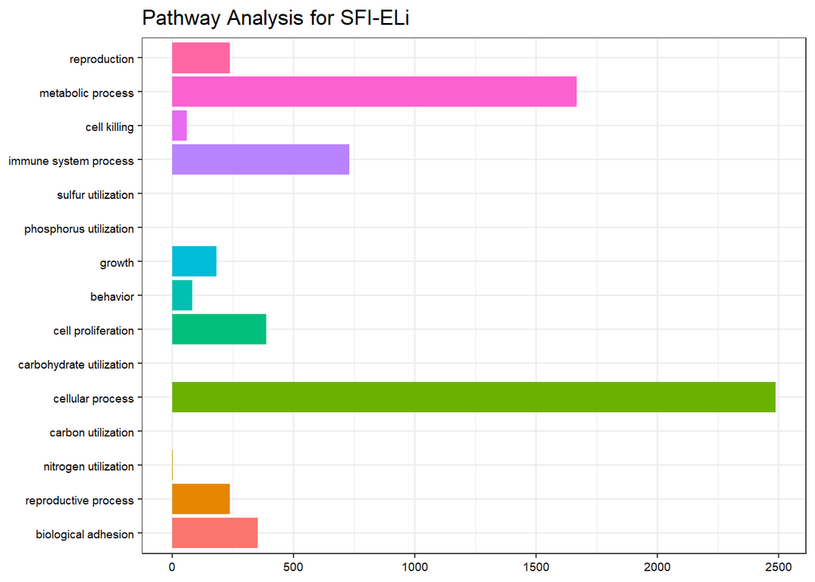

# Conclusiones

- Una debilidad de este análisis va relacionada con los conteos, donde es difícil establecer un rango que se considere adecuado para saber cuál es un valor mínimo para realizar la selección.
- Los grupos de comparación NIT y SFI presentan poca diferencia en expresión génica
- El grupo ELI contiene una alta cantidad de genes expresados diferencialmente respecto a los grupos NIT y SFI.

# Bibliografía

Gonzalo, Ricardo, and Alex Sanchez-Pla. 2020. “Statistical Analysis of Microarray data.” [https://github.com/ASPteaching/Omics{\_}Data{\_}Analysis-Case{\_}Study{\_}1-Microarrays](https://github.com/ASPteaching/Omics%7B\_%7DData%7B\_%7DAnalysis-Case%7B\_%7DStudy%7B\_%7D1-Microarrays).

Hernández, María, Milton Rendón, M Mesa. 2019. “Fisiologia sobre la glandula tiroides y paratiroides.” *Seorl-Pcf* 140: pp. 1. [http://seorl.net/PDF/cabeza cuello y plastica/140 - FISIOLOG{\'{I}}A DE LAS GL{\'{A}}NDULAS TIROIDES Y PARATIROIDES.pdf](http://seorl.net/PDF/cabeza%20cuello%20y%20plastica/140%20-%20FISIOLOG%7B\'%7BI%7D%7DA%20DE%20LAS%20GL%7B\'%7BA%7D%7DNDULAS%20TIROIDES%20Y%20PARATIROIDES.pdf).

Shin, Dong Woo, Sung Min Kim, Jung Ah Kim, Hee Sue Park, Sang Mee Hwang, Kyongok Im, Sungsik Kim, et al. 2019. “Characteristics of Waldenström Macroglobulinemia in Korean Patients According to Mutational Status of MYD88 and CXCR4: Analysis Using Ultra-Deep Sequencing.” *Clinical Lymphoma, Myeloma and Leukemia* 19 (8): e496–e505. https://doi.org/10.1016/j.clml.2019.03.009.

[^1]: https://github.com/EstebanVargasParra/Vargas_Parra_Esteban_ADO_PEC2.git